# Examining BGG Publishers

Phil Henrickson

This notebook provides some basic exploratory analysis of games on boardgamegeek (BGG) in support of my work [predicting ratings for upcoming games] and [predicting games for individual users].

For this write up, I examine games published through 2021 that have achieved at least 30 user ratings by the time of writing.[^ I have additionally excluded some games that were cancelled or never released, or have data quality issues with their profiles on BGG.]

Who are the top publishers of games on BGG and how do they relate to community ratings?

# 1 Publishers

## 1.1 Top Publishers by BGG Outcome

Which publishers have published the most games on BGG? Which publishers are the highest rated? Most popular?

‘Uncredited’ is by far the most common listing for publisher, so I have excluded it from the following visualization.

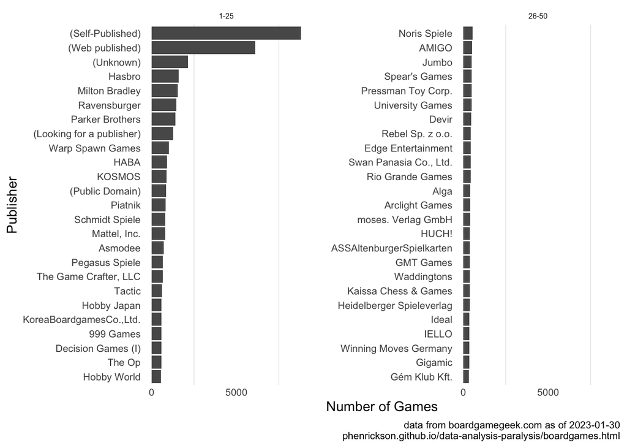

I’ll then plot the distribution of games with the 25 most frequent publishers. What publishers are typically associated with heavier games? What publisher is the highest rated (on average)?

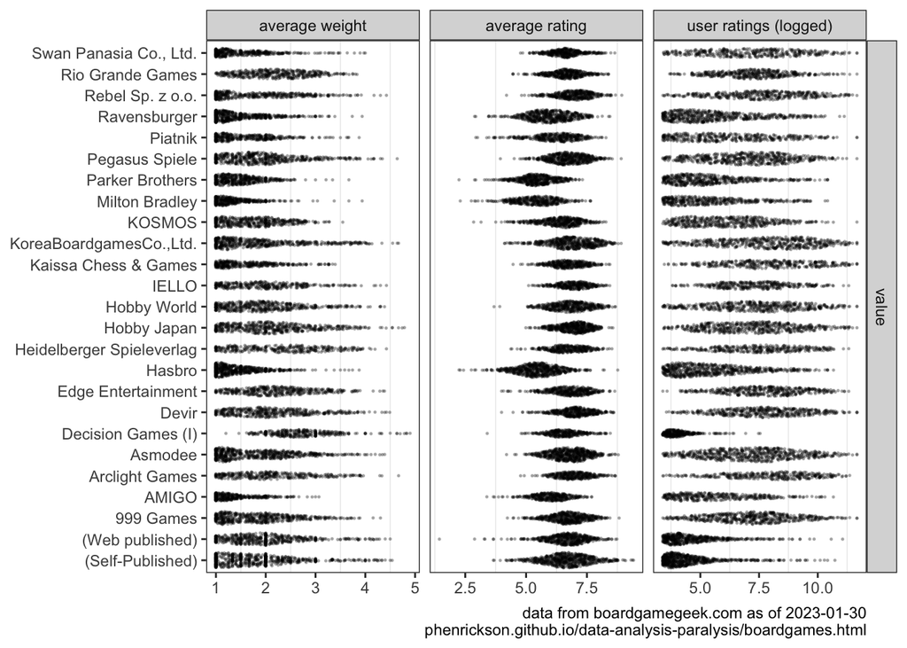

Finally, the following (interactive) table displays the mean of each BGG outcome by publisher. Use the filters below the column names to filter through the table by publisher or set a minimum number of games.

[interactive table not shown]

## 1.2 Publisher Partial Effects

Which publishers have the largest effect on a game’s average?

We could simply look at the games published by each publisher and then take their average rating/average number of user ratings. However, this doesn’t account for the fact that some publishers design more complex games than others, or that recently published games tend to have higher averages.

To get an estimate of each publisher’s partial effect on an outcome, I run penalized regressions lasso) of the BGG average/usersrated on dummies for individual game publishers along with the game’s weight and effects for year published.

I handle time effects in two different ways, first creating an indicator for games published before 1900, then fitting cubic splines to the truncated publishing range of years 1900 to present.

$$Average = \beta_0 + Weight * \beta_1 +
Publisher_1 * \beta_2 + Publisher_2 * \beta_3 * Publisher_k ...
Publisher_n * \beta_n + YearPublished$$

That is, which publisher has the largest partial effect on a game’s average rating conditional on average weight and time?

| Publisher | Games | Average | Ratings |
| --- | --- | --- | --- |
| (Self-Published) | 652 | 0.002 | -0.02 |
| Hasbro | 629 | 0.003 | 0.06 |
| Asmodee | 614 | 0.016 | 0.1 |
| Ravensburger | 553 | 0.019 | 0.08 |
| Pegasus Spiele | 542 | 0.019 | 0.1 |
| 999 Games | 537 | 0.008 | 0.05 |
| Korea Boardgames Co., Ltd. | 534 | 0.017 | 0.04 |
| Hobby Japan | 522 | 0.011 | 0.06 |
| (Web published) | 521 | 0.003 | -0.01 |
| Parker Brothers | 497 | 0.003 | 0.04 |

[output cut: 1663 more lines]